# Temperature and mortality in Chicago: Dealing with missing values

Garyfallos Konstantinoudis

In this document we will show how to deal with missing values in a Bayesian framework using `NIMBLE` (de Valpine et al. 2017). We will use the Chicago dataset as it can be found in the `dlnm` package. Using typing `help(chicagoNMMAPS)` you will find the following information about the dataset:

The data set contains daily mortality (all causes, CVD, respiratory), weather (temperature, dew point temperature, relative humidity) and pollution data (PM10 and ozone) for Chicago in the period 1987-2000 from the National Morbidity, Mortality and Air Pollution Study (NMMAPS).

The purpose of the tutorial is to assess the effect of temperature on the number of deaths of all causes, using the Chicago dataset. At this analysis we are not interested in modelling the lag effect.

## Install and load packages

This practical requires the following packages to be installed and attached: `sf`, `dplyr`, `tidyverse`, `nimble`, `coda`, `spdep`, `patchwork`, `GGally`, `ggmcmc`, `kableExtra`, `splines2` and `dlnm`.

- To install the entire suite of packages, we can use:

```r
install.packages(c("sf", "dplyr", "tidyverse", "nimble", "coda", "spdep", "patchwork",
                   "GGally", "ggmcmc", "dlnm", "splines2", "kableExtra"), dependencies = TRUE, repos = "http://cran.r-project.org")
```

- Then, load the needed packages:

```r
library(sf)           # Simple feature for R
library(dplyr)        # A package for data manipulation
library(tidyverse)    # A package for data manipulation and plotting
library(nimble)       # A package for performing MCMC in R
library(coda)         # A package for summarizing and plotting of MCMC output
                      # and diagnostic tests
library(spdep)        # A package to calculate neighbors
library(patchwork)    # A package to combine plots
library(GGally)       # A package to do pairplots
library(ggmcmc)       # MCMC diagnostics with ggplot
library(dlnm)         # A package for performing dlnms in R
library(splines2)     # A package to fit splines in R
library(kableExtra)   # packages for formatting tables in rmarkdown
library(fastDummies)  # Library to create dummies from a string
```

## Import and explore the Chicago dataset

- Import the health data

```r
head(chicagoNMMAPS, 10)
```

```
##          date time year month doy       dow death cvd resp       temp   dptp
## 1  1987-01-01    1 1987     1   1  Thursday   130  65   13 -0.2777778 31.500
## 2  1987-01-02    2 1987     1   2    Friday   150  73   14  0.5555556 29.875
## 3  1987-01-03    3 1987     1   3  Saturday   101  43   11  0.5555556 27.375
## 4  1987-01-04    4 1987     1   4    Sunday   135  72    7 -1.6666667 28.625
## 5  1987-01-05    5 1987     1   5    Monday   126  64   12  0.0000000 28.875
## 6  1987-01-06    6 1987     1   6   Tuesday   130  63   12  4.4444444 35.125
## 7  1987-01-07    7 1987     1   7 Wednesday   129  72   12  1.3888889 26.750
## 8  1987-01-08    8 1987     1   8  Thursday   109  51   13 -1.6666667 22.000
## 9  1987-01-09    9 1987     1   9    Friday   125  62    7 -3.0555556 29.000
## 10 1987-01-10   10 1987     1  10  Saturday   153  90   11  0.2777778 27.750
##      rhum     pm10        o3
## 1  95.500 26.95607  4.376079
## 2  88.250       NA  4.929803
## 3  89.500 32.83869  3.751079
## 4  84.500 39.95607  4.292746
## 5  74.500       NA  4.751079
## 6  77.375 40.95607  6.334412
## 7  74.500 33.95607  8.594019
## 8  77.875 28.95607 11.797890
## 9  95.125 32.34877  3.876079
## 10 81.875       NA  5.388137
```

Please notice the missing values.

- Calculate the number of missing values per row

```r
summary(chicagoNMMAPS)
```

```
##       date                 time           year          month
##  Min.   :1987-01-01   Min.   :   1   Min.   :1987   Min.   : 1.000
##  1st Qu.:1990-07-02   1st Qu.:1279   1st Qu.:1990   1st Qu.: 4.000
##  Median :1993-12-31   Median :2558   Median :1994   Median : 7.000
##  Mean   :1993-12-31   Mean   :2558   Mean   :1994   Mean   : 6.522
##  3rd Qu.:1997-07-01   3rd Qu.:3836   3rd Qu.:1997   3rd Qu.:10.000
##  Max.   :2000-12-31   Max.   :5114   Max.   :2000   Max.   :12.000
##
##       doy               dow          death            cvd
##  Min.   :  1.0   Sunday   :731   Min.   : 69.0   Min.   : 25.0
##  1st Qu.: 92.0   Monday   :730   1st Qu.:105.0   1st Qu.: 44.0
##  Median :183.0   Tuesday  :730   Median :114.0   Median : 50.0
##  Mean   :183.1   Wednesday:730   Mean   :115.4   Mean   : 50.9
##  3rd Qu.:274.0   Thursday :731   3rd Qu.:124.0   3rd Qu.: 57.0
##  Max.   :366.0   Friday   :731   Max.   :411.0   Max.   :312.0
##                  Saturday :731
##       resp             temp              dptp             rhum
##  Min.   : 0.000   Min.   :-26.667   Min.   :-25.62   Min.   : 25.62
##  1st Qu.: 7.000   1st Qu.:  1.667   1st Qu.: 27.25   1st Qu.: 58.12
##  Median : 9.000   Median : 10.556   Median : 39.75   Median : 69.75
##  Mean   : 9.178   Mean   : 10.107   Mean   : 40.41   Mean   : 69.17
##  3rd Qu.:11.000   3rd Qu.: 19.444   3rd Qu.: 55.75   3rd Qu.: 80.38
##  Max.   :34.000   Max.   : 33.333   Max.   : 78.25   Max.   :100.00
##                                                      NA's   :1096
##       pm10              o3
##  Min.   : -3.05   Min.   :-0.832
##  1st Qu.: 20.77   1st Qu.:11.960
##  Median : 30.25   Median :19.045
##  Mean   : 33.74   Mean   :20.143
##  3rd Qu.: 42.42   3rd Qu.:26.624
##  Max.   :356.18   Max.   :65.808
##  NA's   :251
```

There are 1096 missing values for the mean daily relative humidity and 251 for PM$_10$.

## Complete cases analysis

### The model

where $\alpha$ is an intercept term, $\beta_j$ covariates for the effect of the days, $\gamma$ a linear term for PM, $\xi_t$ a temporal trend, and $w_t$ a smooth function for the effect of temperature.

### The code

- Nimble model

```r
CompleteCase.code <- nimbleCode(
  {
    for (t in 1:Total){

      O[t] ~ dpois(mu[t])
      log(mu[t]) <- alpha + inprod(beta[1:6], X[t, 1:6]) + gamma*PM[t] + xi[time_cat[t]] +
        w[tmp.ord[t]]

    }

   # intrinsic CAR prior on the effect of time
   xi[1:N] ~ dcar_normal(adj2[1:M], weights2[1:M], num2[1:N], tau.xi, c = 2, zero_mean = 1)

   # intrinsic CAR prior on the effect of temperature
   w[1:K] ~ dcar_normal(adj[1:L], weights[1:L], num[1:K], tau.w, c = 2, zero_mean = 1)

    # Priors:
    alpha ~ dflat()                                      # Unif(-inf, +inf)
    exp.alpha <- exp(alpha)                              # overall counts across time period

    for(j in 1:6){
        beta[j] ~ dnorm(0, tau = 5)
      exp.beta[j] <- exp(beta[j])                        # the coefficients of the splines
    }

    gamma ~ dnorm(0, tau = 5)
    exp.gamma <- exp(gamma)

    # the priors are informative to help smoothing
    tau.xi <- 1/sigma2.xi
    sigma2.xi ~ dgamma(1,0.5)

    tau.w <- 1/sigma2.w
    sigma2.w ~ dgamma(1,1)
  }
)
```

- Define a new data frame without the PM missings

```r
dat.complete.case <- chicagoNMMAPS[!is.na(chicagoNMMAPS$pm10),]
dat.complete.case <- dat.complete.case[order(dat.complete.case$time),]
dat.complete.case$time <- 1:nrow(dat.complete.case)

dat.complete.case$time_cat <- cut(
  dat.complete.case$time,
  breaks = seq(from = min(dat.complete.case$time),
               to  = max(dat.complete.case$time),
               length.out = 700), # a weekly term
  labels = 1:699,
  include.lowest = TRUE
)

dat.complete.case$time_cat <-
  as.numeric(droplevels(dat.complete.case$time_cat))

dat.complete.case <- dat.complete.case[order(dat.complete.case$time_cat),]
```

- Define the ordered variable for RW.

```r
dat.complete.case$temp_cat <- cut(
  dat.complete.case$temp,
  breaks = seq(from = min(dat.complete.case$temp),
               to  = max(dat.complete.case$temp),
               length.out = 100),
  labels = 1:99,
  include.lowest = TRUE
)

dat.complete.case$temp_cat_order <-
  as.numeric(droplevels(dat.complete.case$temp_cat))

dat.complete.case <- dat.complete.case[order(dat.complete.case$temp_cat_order),]
```

- Define the weights for the covariance matrix.

```r
RW2 <- function(k){

    rest.comp <- list()
    for(i in 3:(k-2)){
      rest.comp[[i]] <- c(i-2, i-1, i+1, i+2)
    }
    rest.comp <- unlist(rest.comp)

    adj = c(2, 3, 1, 3, 4,
            rest.comp,
            c(k-3, k-2, k, k-2, k-1)
            )

    num = c(2, 3, rep(4, times = c(k-4)), 3, 2)

    weights = c(c(2, -1, 2, 4, -1),
                rep(c(-1, 4, 4, -1), times = c(k-4)),
                c(-1, 4, 2, -1, 2))

    retlist <- list()
    retlist$adj <- adj
    retlist$num <- num
    retlist$weights <- weights
    return(retlist)

}

# temperature
K <- max(dat.complete.case$temp_cat_order)
Wnb <- RW2(K)

# time
N <- max(dat.complete.case$time_cat)
Wnb2 <- RW2(N)
```

- Data objects:

```r
# Format the data for NIMBLE in a list
ChicagoData = list(
                 O = dat.complete.case$death,
                 X = as.matrix(fastDummies::dummy_cols(dat.complete.case$dow)[,-c(1:2)]),
                 PM = scale(dat.complete.case$pm10)[,1]
)

ChicagoConsts <-list(
                 N = N,
                 M = length(Wnb2$adj),

                 K = K,
                 L = length(Wnb$adj),

                 adj = Wnb$adj,
                 num = Wnb$num,
                 weights = Wnb$weights,

                 adj2 = Wnb2$adj,
                 num2 = Wnb2$num,
                 weights2 = Wnb2$weights,

                 tmp.ord = dat.complete.case$temp_cat_order,
                 time_cat = dat.complete.case$time_cat,
                 Total = nrow(dat.complete.case)
)
```

- Initialize the parameters:

```r
inits <- list(

  list(alpha=0.01,
       sigma2.w=0.1,
       sigma2.xi=0.1,
       xi=rep(0.1, times = N),
       w=rep(0.1, times = K),
       beta=rep(0, times = 6),
       gamma=0),

  list(alpha=1,
       sigma2.w=1,
       sigma2.xi=1,
       xi=rep(0.5, times = N),
       w=rep(0.5, times = K),
       beta=rep(-1, times = 6),
       gamma=2)
)
```

- Set the parameters that will be monitored:

```r
params <- c("mu", paste0("exp.beta[", 1:6, "]"), "alpha",
            "exp.gamma", "xi", "w", "sigma2.xi", "sigma2.w")
```

- Specify the MCMC setting:

```r
# MCMC setting
ni <- 150000  # nb iterations
nt <- 10     # thinning interval
nb <- 50000   # nb iterations as burn-in
nc <- 2      # nb chains
```

- Run the MCMC simulations calling Nimble from R using the function `nimbleMCMC()`. (1.7 hours)

```r
t_0 <- Sys.time()
CompleteCase.model <- nimbleMCMC(code = CompleteCase.code,
                      data = ChicagoData,
                      constants = ChicagoConsts,
                      inits = inits,
                      monitors = params,
                      niter = ni,
                      nburnin = nb,
                      thin = nt,
                      nchains = nc,
                      setSeed = 9,
                      progressBar = TRUE,
                      samplesAsCodaMCMC = TRUE,
                      summary = TRUE,
                      WAIC = TRUE
                      )
t_1 <- Sys.time()
time_lcc <- t_1 - t_0
```

### Convergence

- Check convergence

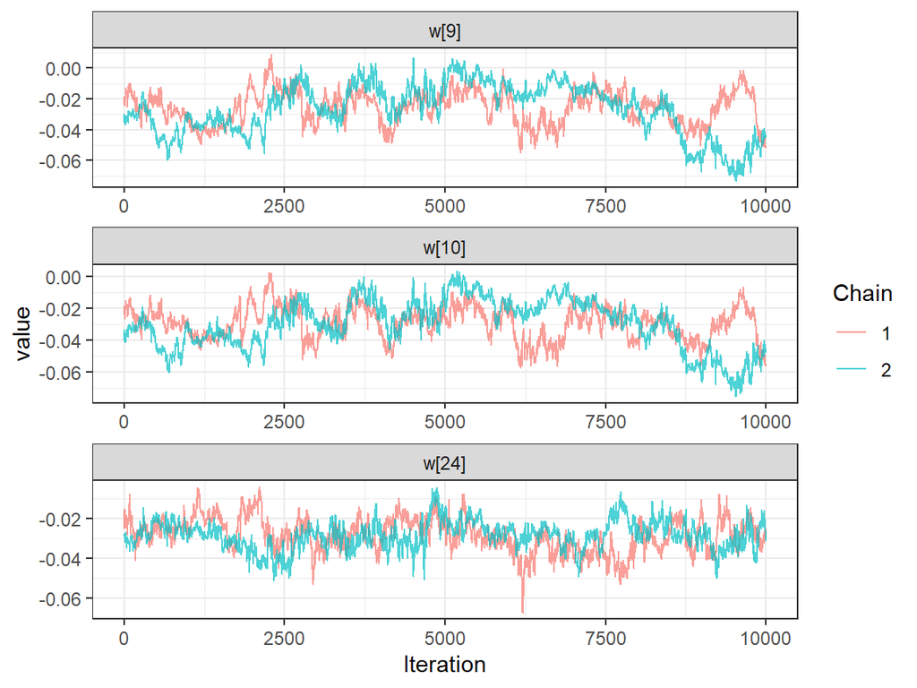

```r
ggs_mod <- ggs(CompleteCase.model$samples)

ggs_mod %>% filter(Parameter == c("w[10]", "w[9]", "w[24]")) %>%
  ggs_traceplot() + theme_bw()
```

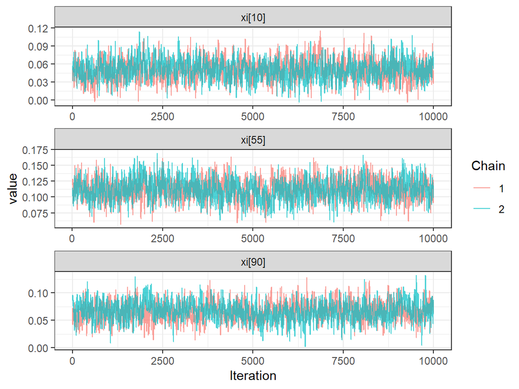

```r
ggs_mod %>% filter(Parameter == c("xi[10]", "xi[90]", "xi[55]")) %>%
  ggs_traceplot() + theme_bw()
```

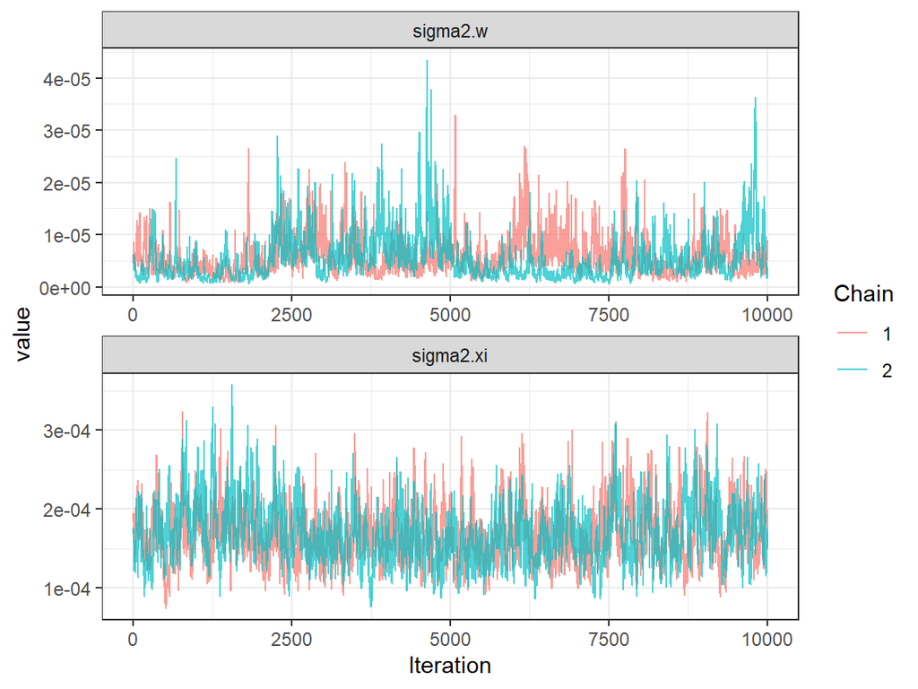

```r
ggs_mod %>% filter(Parameter == c("sigma2.xi", "sigma2.w")) %>%
  ggs_traceplot() + theme_bw()
```

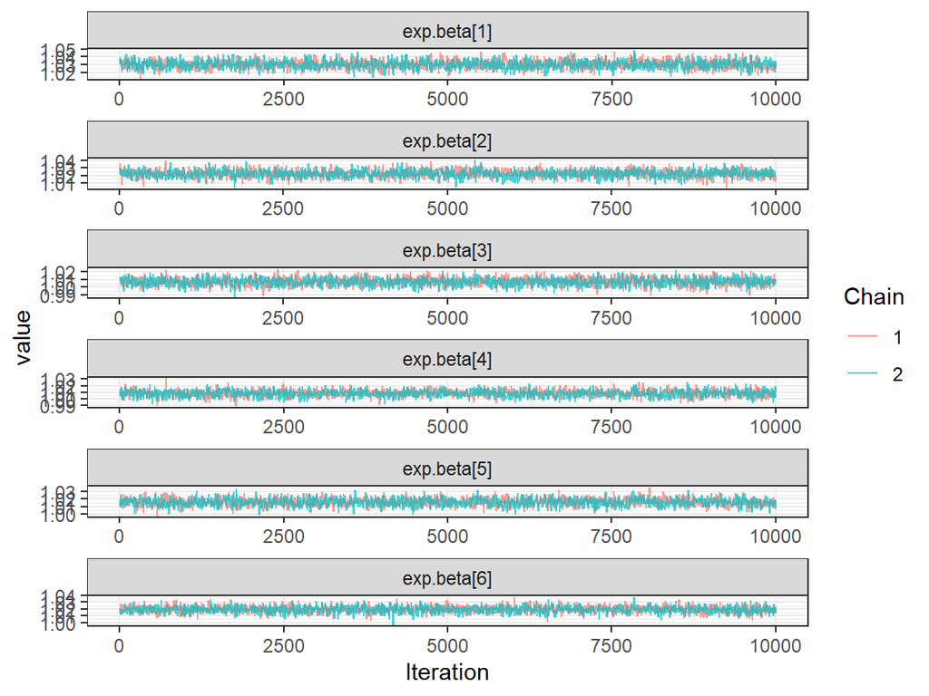

```r
ggs_mod %>% filter(Parameter == c(paste0("exp.beta[", 1:6, "]"))) %>%
  ggs_traceplot() + theme_bw()
```

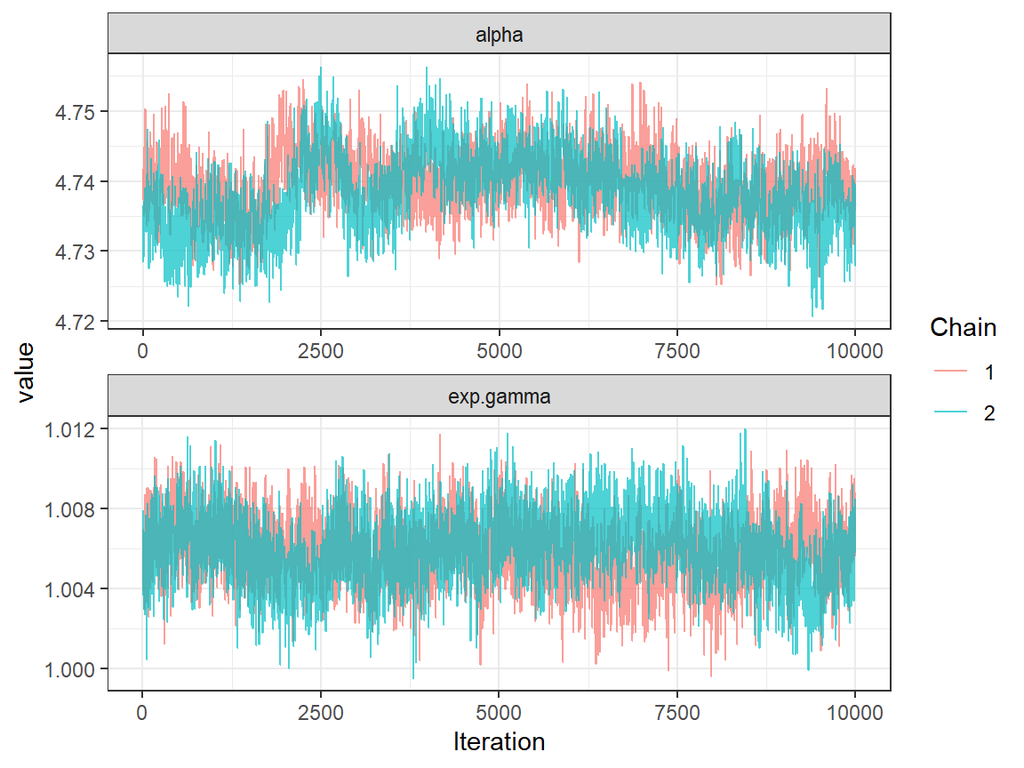

```r
ggs_mod %>% filter(Parameter == c("alpha","exp.gamma")) %>%
  ggs_traceplot() + theme_bw()
```

### Results

- Extract results (temperature effect)

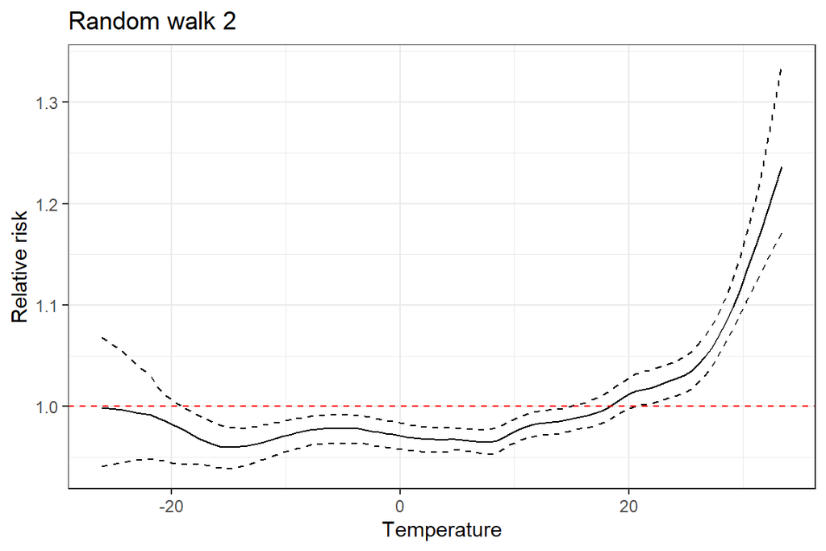

```r
tmp_cat = cut(
  dat.complete.case$temp,
  breaks = seq(from = min(dat.complete.case$temp),
               to  = max(dat.complete.case$temp),
               length.out = 100),
  labels = seq(from = min(dat.complete.case$temp),
               to  = max(dat.complete.case$temp),
               length.out = 100)[-1],
  include.lowest = TRUE
)

tmp_cat <- droplevels(tmp_cat)
tmp_cat <-
round(as.numeric(as.character(levels(tmp_cat))), digits = 3)

datRW2 = data.frame(temp = tmp_cat,
                 median = CompleteCase.model$summary$all.chains[paste0("w[", 1:K, "]"), "Median"],
                 LL = CompleteCase.model$summary$all.chains[paste0("w[", 1:K, "]"), "95%CI_low"],
                 UL = CompleteCase.model$summary$all.chains[paste0("w[", 1:K, "]"), "95%CI_upp"])

ggplot() + geom_line(data = datRW2, aes(x = temp, y = exp(median))) +
  geom_line(data = datRW2, aes(x = temp, y = exp(LL)), linetype = 2) +
  geom_line(data = datRW2, aes(x = temp, y = exp(UL)), linetype = 2) +
  theme_bw() + xlab("Temperature") + ylab("Relative risk") +
  geom_hline(yintercept = 1, col = "red", linetype = 2) +
  ggtitle("Random walk 2")
```

- Extract results (temporal effect)

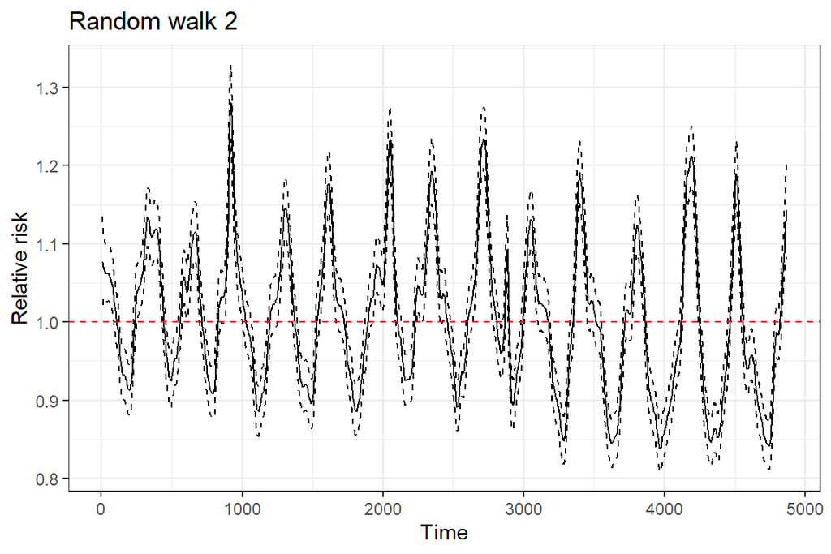

```r
time_cat = cut(
  dat.complete.case$time,
  breaks = seq(from = min(dat.complete.case$time),
               to  = max(dat.complete.case$time),
               length.out = 700),
  labels = seq(from = min(dat.complete.case$time),
               to  = max(dat.complete.case$time),
               length.out = 700)[-1],
  include.lowest = TRUE
)

time_cat <- droplevels(time_cat)
time_cat <-
round(as.numeric(as.character(levels(time_cat))), digits = 3)

datRW2 = data.frame(time_cat = time_cat,
          median = CompleteCase.model$summary$all.chains[paste0("xi[", 1:N, "]"), "Median"],
          LL = CompleteCase.model$summary$all.chains[paste0("xi[", 1:N, "]"), "95%CI_low"],
          UL = CompleteCase.model$summary$all.chains[paste0("xi[", 1:N, "]"), "95%CI_upp"])

ggplot() + geom_line(data = datRW2, aes(x = time_cat, y = exp(median))) +
  geom_line(data = datRW2, aes(x = time_cat, y = exp(LL)), linetype = 2) +
  geom_line(data = datRW2, aes(x = time_cat, y = exp(UL)), linetype = 2) +
  theme_bw() + xlab("Time") + ylab("Relative risk") +
  geom_hline(yintercept = 1, col = "red", linetype = 2) +
  ggtitle("Random walk 2")
```

## Imputation

### The model

We will investigate PM a bit more and impute the missings

```r
summary(chicagoNMMAPS$pm10)
```

```
##    Min. 1st Qu.  Median    Mean 3rd Qu.    Max.    NA's
##   -3.05   20.77   30.25   33.74   42.42  356.18     251
```

Here we observe that there are several negatives. These are obviously illegal values and thus I would treat as NAs.

```r
chicagoNMMAPS$pm10[chicagoNMMAPS$pm10<0] <- NA
```

The idea now is to model the log PM and impute it. This can be done in many different ways. Here we will impute based on its temporal trend. One could also think of using the given covariates to inform imputation.

- Define the data.frame

```r
chicagoNMMAPS$time_cat <- cut(
  chicagoNMMAPS$time,
  breaks = seq(from = min(chicagoNMMAPS$time),
               to  = max(chicagoNMMAPS$time),
               length.out = 700), # a weekly term
  labels = 1:699,
  include.lowest = TRUE
)

chicagoNMMAPS$time_cat <-
  as.numeric(droplevels(chicagoNMMAPS$time_cat))
```

- Define the ordered variable for RW.

```r
chicagoNMMAPS$temp_cat <- cut(
  chicagoNMMAPS$temp,
  breaks = seq(from = min(chicagoNMMAPS$temp),
               to  = max(chicagoNMMAPS$temp),
               length.out = 100),
  labels = 1:99,
  include.lowest = TRUE
)

chicagoNMMAPS$temp_cat_order <-
  as.numeric(droplevels(chicagoNMMAPS$temp_cat))

chicagoNMMAPS <- chicagoNMMAPS[order(chicagoNMMAPS$temp_cat_order),]
```

- Define the weights for the covariance matrix.

```r
# temperature
K <- max(chicagoNMMAPS$temp_cat_order)
Wnb <- RW2(K)

# time
N <- max(chicagoNMMAPS$time_cat)
Wnb2 <- RW2(N)
```

- Write the model for imputing.

```r
Imputation.code <- nimbleCode(
  {
    for (t in 1:R){ # R is the total number of rows missings included

      O[t] ~ dpois(mu[t])
      log(mu[t]) <- alpha + inprod(beta[1:6], X[t,1:6]) + gamma*pm.scaled[t] + xi[time_cat[t]] +
        w[tmp.ord[t]]

      log.PM[t] ~ dnorm(log.pm.mean[t], log.pm.prec)
      log.pm.mean[t] <- alpha.pm + u[time_cat[t]]
      pm.natscale[t] <- exp(log.PM[t])

    }

   pm.scaled[1:R] <- (pm.natscale[1:R] - mean(pm.natscale[1:R]))/sd(pm.natscale[1:R])

   # intrinsic CAR prior on the effect of time
   xi[1:N] ~ dcar_normal(adj2[1:M], weights2[1:M], num2[1:N], tau.xi, zero_mean = 1)
   u[1:N] ~ dcar_normal(adj2[1:M], weights2[1:M], num2[1:N], tau.u, zero_mean = 1)

   # intrinsic CAR prior on the effect of temperature
   w[1:K] ~ dcar_normal(adj[1:L], weights[1:L], num[1:K], tau.w, zero_mean = 1)


   # Priors:
   # imputation
   alpha.pm ~ dnorm(0, 0.0001)
   log.pm.prec <- 1/(sd.pm*sd.pm)
   sd.pm ~ dunif(0.00001, 50)
   tau.u <- 1/sigma2.u
   sigma2.u ~ dgamma(1,0.5)

   # main model
   alpha ~ dflat()
   exp.alpha <- exp(alpha)

   for(k in 1:6){
       beta[k] ~ dnorm(0, tau = 5)
     exp.beta[k] <- exp(beta[k])
   }

   gamma ~ dnorm(0, tau = 5)
   exp.gamma <- exp(gamma)

   # the priors are informative to help smoothing
   tau.xi <- 1/sigma2.xi
   sigma2.xi ~ dgamma(1,0.5)

   tau.w <- 1/sigma2.w
   sigma2.w ~ dgamma(1,0.5)
  }
)
```

- Data objects:

```r
chicagoNMMAPS <- chicagoNMMAPS[order(chicagoNMMAPS$pm10),]

# Format the data for NIMBLE in a list
ChicagoData = list(
                 O = chicagoNMMAPS$death,
                 X = as.matrix(fastDummies::dummy_cols(chicagoNMMAPS$dow)[,-c(1:2)]),
                 log.PM = log(chicagoNMMAPS$pm10)
)

ChicagoConsts <-list(

                 N = N,
                 M = length(Wnb2$adj),

                 K = K,
                 L = length(Wnb$adj),

                 adj = Wnb$adj,
                 num = Wnb$num,
                 weights = Wnb$weights,

                 adj2 = Wnb2$adj,
                 num2 = Wnb2$num,
                 weights2 = Wnb2$weights,

                 tmp.ord = chicagoNMMAPS$temp_cat_order,
                 time_cat = chicagoNMMAPS$time_cat,

                 R = nrow(chicagoNMMAPS),
                 R1 = sum(!is.na(chicagoNMMAPS$pm10))

)
```

- Initialize the parameters:

```r
inits <- list(

  list(alpha=0.01,
       alpha.pm=log(50),
       sd.pm=1,
       sigma2.u=0.1,
       u=rep(0.1, times = N),
       sigma2.w=0.1,
       sigma2.xi=0.1,
       xi=rep(0.1, times = N),
       w=rep(0.1, times = K),
       beta=rep(0, times = 6),
       gamma=0
       ),

  list(alpha=1,
       alpha.pm=log(100),
       sd.pm=2,
       sigma2.u=1,
       u=rep(0.5, times = N),
       sigma2.w=1,
       sigma2.xi=1,
       xi=rep(0.5, times = N),
       w=rep(0.5, times = K),
       beta=rep(-1, times = 6),
       gamma=2
       )
)
```

- Set the parameters that will be monitored:

```r
params <- c("mu", paste0("exp.beta[", 1:6, "]"), "alpha",
            "exp.gamma", "xi", "w", "sigma2.xi", "sigma2.w",
            "u", "alpha.pm", "sd.pm", "sigma2.u", "pm.natscale")
```

- nimble call (1.4 days)

```r
t_0 <- Sys.time()
Imputation.model <- nimbleMCMC(code = Imputation.code,
                      data = ChicagoData,
                      constants = ChicagoConsts,
                      inits = inits,
                      monitors = params,
                      niter = ni,
                      nburnin = nb,
                      thin = nt,
                      nchains = nc,
                      setSeed = 9,
                      progressBar = TRUE,
                      samplesAsCodaMCMC = TRUE,
                      summary = TRUE,
                      WAIC = TRUE
                      )
t_1 <- Sys.time()
time_lim <- t_1 - t_0
```

- Check convergence

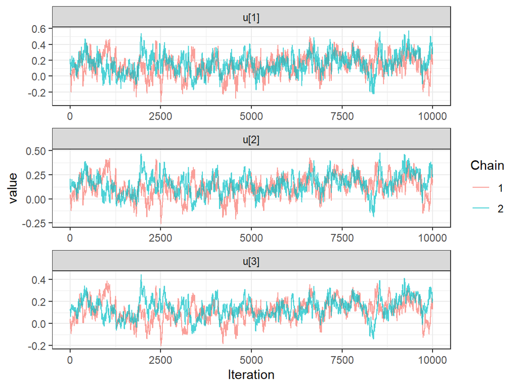

```r
Imputation.model_ggs <- ggs(Imputation.model$samples)

Imputation.model_ggs %>% filter(Parameter == c("u[1]", "u[2]", "u[3]")) %>%
  ggs_traceplot() + theme_bw()
```

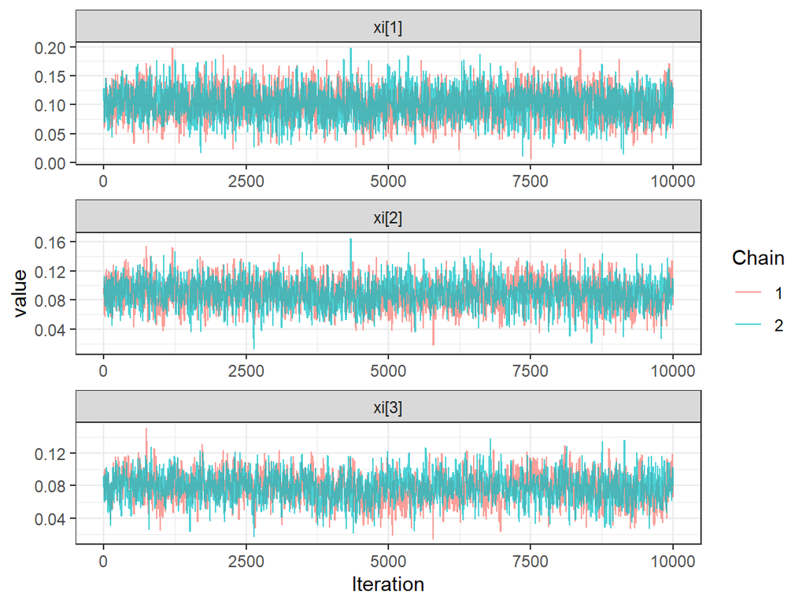

```r
Imputation.model_ggs %>% filter(Parameter == c("xi[1]", "xi[2]", "xi[3]")) %>%
  ggs_traceplot() + theme_bw()
```

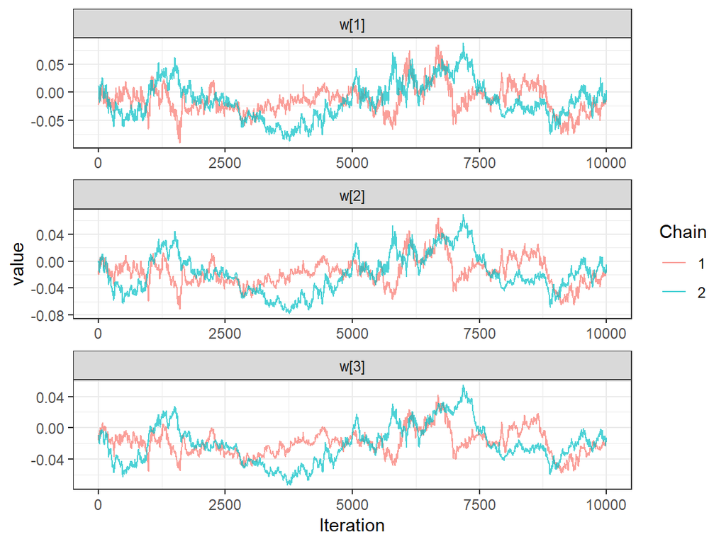

```r
Imputation.model_ggs %>% filter(Parameter == c("w[1]", "w[2]", "w[3]")) %>%
  ggs_traceplot() + theme_bw()
```

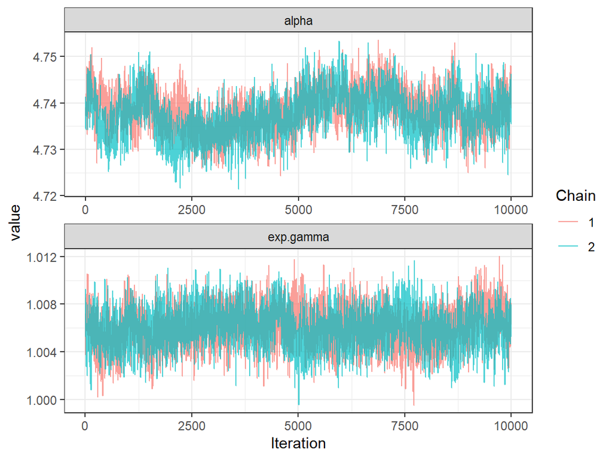

```r
Imputation.model_ggs %>% filter(Parameter == c("alpha", "exp.gamma")) %>%
  ggs_traceplot() + theme_bw()
```

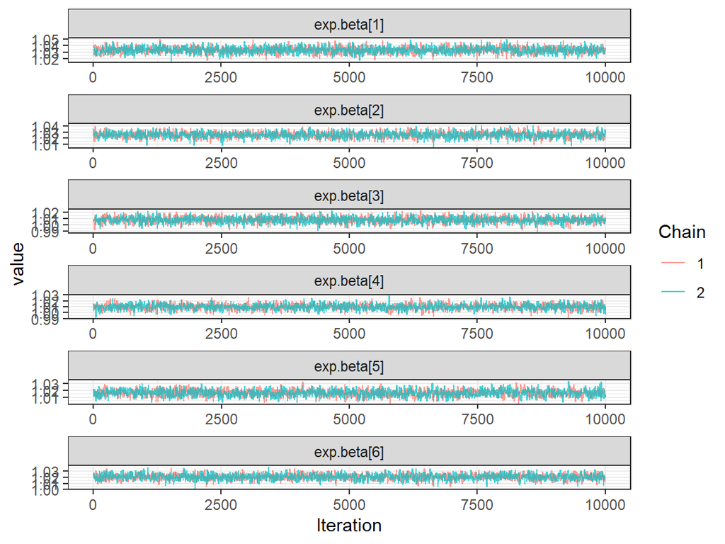

```r
Imputation.model_ggs %>% filter(Parameter == c(paste0("exp.beta[", 1:6, "]"))) %>%
  ggs_traceplot() + theme_bw()
```

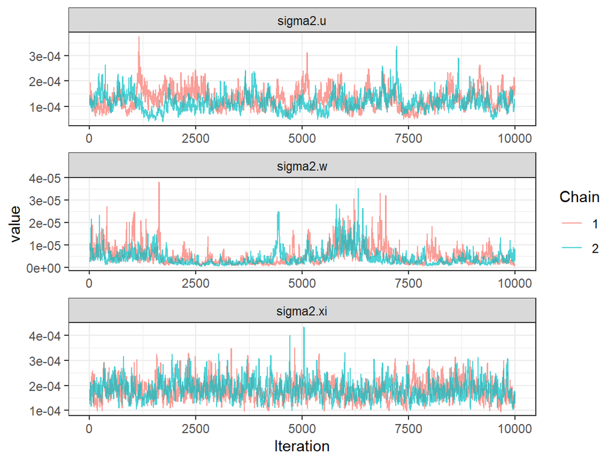

```r
Imputation.model_ggs %>% filter(Parameter == c("sigma2.xi", "sigma2.w", "sigma2.u")) %>%
  ggs_traceplot() + theme_bw()
```

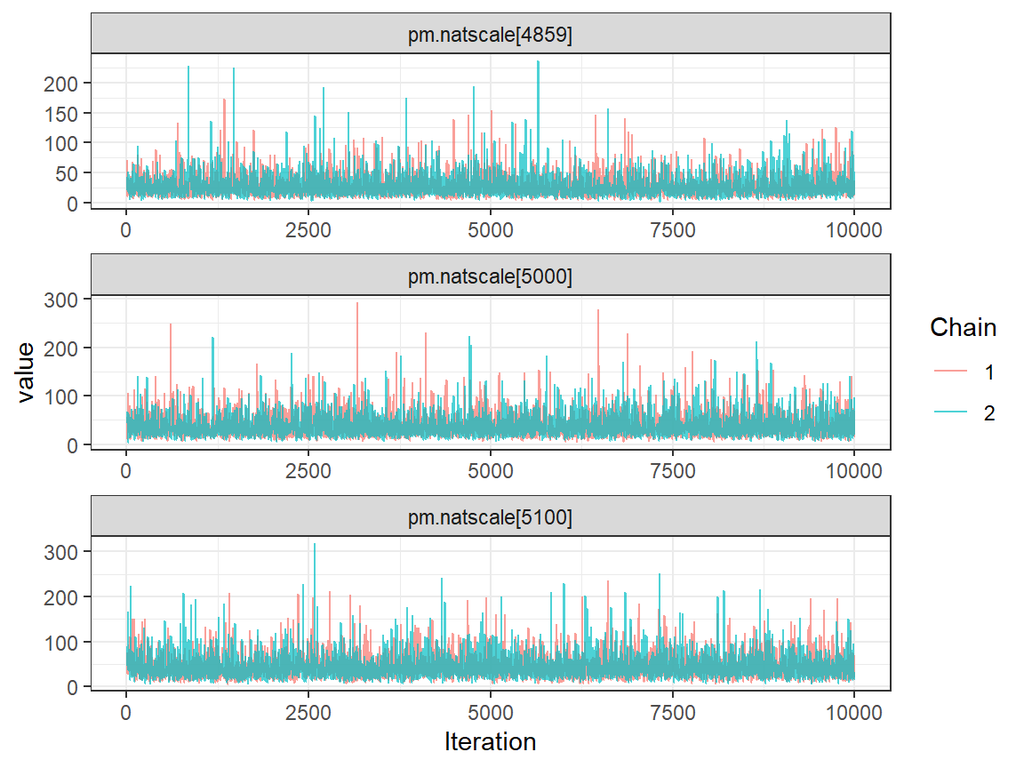

```r
Imputation.model_ggs %>% filter(Parameter == c("pm.natscale[4859]", "pm.natscale[5000]",
                                               "pm.natscale[5100]")) %>%
  ggs_traceplot() + theme_bw()
```

- Extract results (temperature effect)

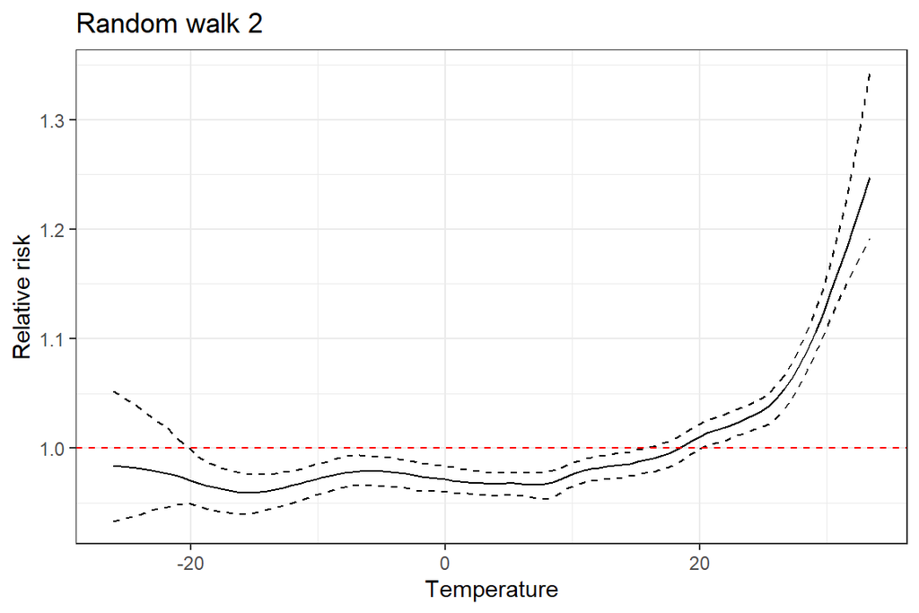

```r
tmp_cat = cut(
  chicagoNMMAPS$temp,
  breaks = seq(from = min(chicagoNMMAPS$temp),
               to  = max(chicagoNMMAPS$temp),
               length.out = 100),
  labels = seq(from = min(chicagoNMMAPS$temp),
               to  = max(chicagoNMMAPS$temp),
               length.out = 100)[-1],
  include.lowest = TRUE
)

tmp_cat <- droplevels(tmp_cat)
tmp_cat <-
round(as.numeric(as.character(levels(tmp_cat))), digits = 3)

datRW2 = data.frame(temp = tmp_cat,
                 median = Imputation.model$summary$all.chains[paste0("w[", 1:K, "]"), "Median"],
                 LL = Imputation.model$summary$all.chains[paste0("w[", 1:K, "]"), "95%CI_low"],
                 UL = Imputation.model$summary$all.chains[paste0("w[", 1:K, "]"), "95%CI_upp"])

ggplot() + geom_line(data = datRW2, aes(x = temp, y = exp(median))) +
  geom_line(data = datRW2, aes(x = temp, y = exp(LL)), linetype = 2) +
  geom_line(data = datRW2, aes(x = temp, y = exp(UL)), linetype = 2) +
  theme_bw() + xlab("Temperature") + ylab("Relative risk") +
  geom_hline(yintercept = 1, col = "red", linetype = 2) +
  ggtitle("Random walk 2")
```

- Extract results (temporal effect)

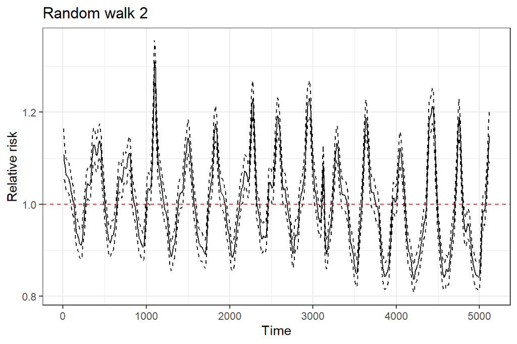

```r
time_cat = cut(
  chicagoNMMAPS$time,
  breaks = seq(from = min(chicagoNMMAPS$time),
               to  = max(chicagoNMMAPS$time),
               length.out = 700),
  labels = seq(from = min(chicagoNMMAPS$time),
               to  = max(chicagoNMMAPS$time),
               length.out = 700)[-1],
  include.lowest = TRUE
)

time_cat <- droplevels(time_cat)
time_cat <-
round(as.numeric(as.character(levels(time_cat))), digits = 3)

datRW2 = data.frame(time_cat = time_cat,
          median = Imputation.model$summary$all.chains[paste0("xi[", 1:N, "]"), "Median"],
          LL = Imputation.model$summary$all.chains[paste0("xi[", 1:N, "]"), "95%CI_low"],
          UL = Imputation.model$summary$all.chains[paste0("xi[", 1:N, "]"), "95%CI_upp"])

ggplot() + geom_line(data = datRW2, aes(x = time_cat, y = exp(median))) +
  geom_line(data = datRW2, aes(x = time_cat, y = exp(LL)), linetype = 2) +
  geom_line(data = datRW2, aes(x = time_cat, y = exp(UL)), linetype = 2) +
  theme_bw() + xlab("Time") + ylab("Relative risk") +
  geom_hline(yintercept = 1, col = "red", linetype = 2) +
  ggtitle("Random walk 2")
```

```r
tab <-
data.frame(
round(
(rbind(
CompleteCase.model$summary$all.chains["exp.gamma", c("Median", "95%CI_low", "95%CI_upp")],
Imputation.model$summary$all.chains["exp.gamma", c("Median", "95%CI_low", "95%CI_upp")]
) - 1)*100, digits = 2)
)

rownames(tab) <- c("Complete cases", "Imputation")

knitr::kable(tab, caption = "Effect of PM") %>%  kable_styling(bootstrap_options = "striped", full_width = F, position = "center")
```

Effect of PM

|  | Median | X95.CI_low | X95.CI_upp |
| --- | --- | --- | --- |
| Complete cases | 0.59 | 0.26 | 0.93 |
| Imputation | 0.60 | 0.28 | 0.92 |

## References

de Valpine, P., D. Turek, C. J. Paciorek, C. Anderson-Bergman, D. Temple Lang, and R. Bodik. 2017. “Programming with Models: Writing Statistical Algorithms for General Model Structures with NIMBLE.” *Journal of Computational and Graphical Statistics* 26: 403–17. https://doi.org/10.1080/10618600.2016.1172487.